# Chapter3

LuisF

27/5/2020

#### Ejemplo webstickiness

Una empresa desea saber qué diseño web le va traer más ventas. Para poder realizar esto en un tiempo corto, se va utilizar una variable proxy, ya que el hecho de intentar con un diseño y luego con otro, va tomar mucho tiempo. Una variable proxy es aquella que te va ayudar a inferir tu variable real de interes.

En este ejemplo, la variable proxy que utilizan es el tiempo que las personas pasan en la página A y B.

```r
#Leyendo df
df <- read.table('D:/Documentos/Python for Data Projects/datos_practical_statistics/web_page_data.csv', sep = ",", header = T)
head(df)
```

```
##     Page Time
## 1 Page A 0.21
## 2 Page B 2.53
## 3 Page A 0.35
## 4 Page B 0.71
## 5 Page A 0.67
## 6 Page B 0.85
```

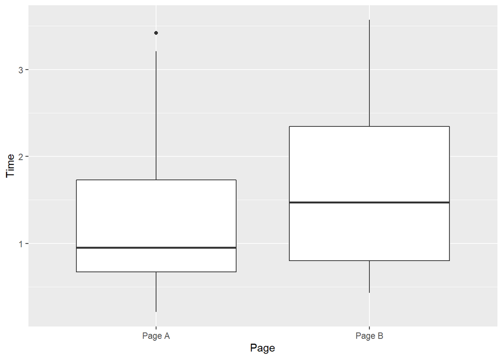

```r
##Hay un total de 36 sesiones contadas: 21 para A y 15 para B.
#Usando unos boxplot podemos visualizar los tiempos en cada página
ggplot(df,  aes(x=Page, y=Time)) +
  geom_boxplot()
```

```r
#restando las medias:
mean_a <- mean(df[df['Page'] == 'Page A', 'Time'])
mean_b <- mean(df[df['Page'] == 'Page B', 'Time'])
(mean_b - mean_a)*60
```

```
## [1] 21.4
```

```r
#La diferencia de tiempo de sesión entre B respecto a A es 21.4 segundos.
#Podrías concluir con esto que B es significativamente mejor que A? Acaso la diferencia esta dentro de lo random? es decir,
#es estadísticamente significativo?
#Vamos a aplicar un test de permutación
```

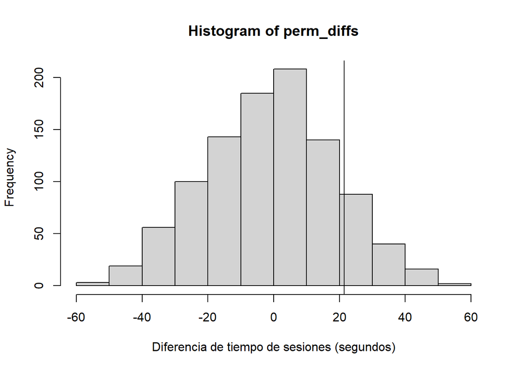

```r
#Primero creamos una función para generar una permutación
perm_fun <- function(x,n1,n2) {
  n <- n1+n2
  idx_b <- sample(1:n, n1)
  #print(idx_b)
  idx_a <- setdiff(1:n, idx_b)
  #print(idx_a)
  mean_diff <- mean(x[idx_b]) - mean(x[idx_a])
  return(mean_diff)
}

#perm_fun(df[,'Time'],21,15)

#Ahora generamos n veces esta permutación (test de permutación random):

perm_diffs <- rep(0,1000)
for (i in 1:1000) {
  perm_diffs[i] = perm_fun(df[,'Time'],21,15)*60
}
hist(perm_diffs, xlab='Diferencia de tiempo de sesiones (segundos)')
abline(v=(mean_b - mean_a)*60)
```

Las permutaciones demuestran que la diferencia de promedios de tiempo caen mayormente entre -40 y 40. De manera random, esto es lo normal. La diferencia de medias entre A y B es 21, un valor que caen entre el rango de -40 y 40, por lo tanto, no es estadísticamente significativo.

Cabe mencionar que hay dos tipos de permutación random:

- Test de Permutación Exhaustiva: en lugar de unir y dividir de manera random los datos, se buscan las posibles combinaciones. Esto es practico solo para muestras pequeñas.
- Test de Permutación Bootstrap: en lugar de realizar el sampleo sin reemplazo, se hace con reemplazo.

El autor menciona que la diferencia de estas dos no tiene consecuencias mayores para la ciencia de datos…

### Estadísticamente significativo y el P-Value/Statistical Significance and P-Value

Es el método utilizado por las personas que se dedican a la estadística para demostrar que la diferencia entre A y B es realmente significativa. Es decir, la diferencia que lo random puede llegar a decir entre A y B, si tendra un impacto significativo en los resultados, o no.

#### Ejemplo de tasas de conversión entre páginas de e-commerce

```r
df <- data.frame(
  Outcome = c("Conversion","No Conversion"),
  Price_A = c(200,23539),
  Price_B = c(182,22406)
)
df
```

```
##         Outcome Price_A Price_B
## 1    Conversion     200     182
## 2 No Conversion   23539   22406
```

El precio A convierte casi un 5% más que el precio B:

```r
tasa_conversion_a <- (df$Price_A[1]/sum(df$Price_A))*100
tasa_conversion_b <- (df$Price_B[1]/sum(df$Price_B))*100
tasa_conversion_a - tasa_conversion_b
```

```
## [1] 0.03675791
```

Sin embargo, aunque aca tenemos más de 45,000 data points y puede ser considerado bigdata (lo dudo…), aun asi necesitamos usar un test estadístico, ya que las tasas de conversión son muy bajas (menor a 1%). Hipótesis nula: la diferencai de tasas es mayor a 5% el 95% de las veces

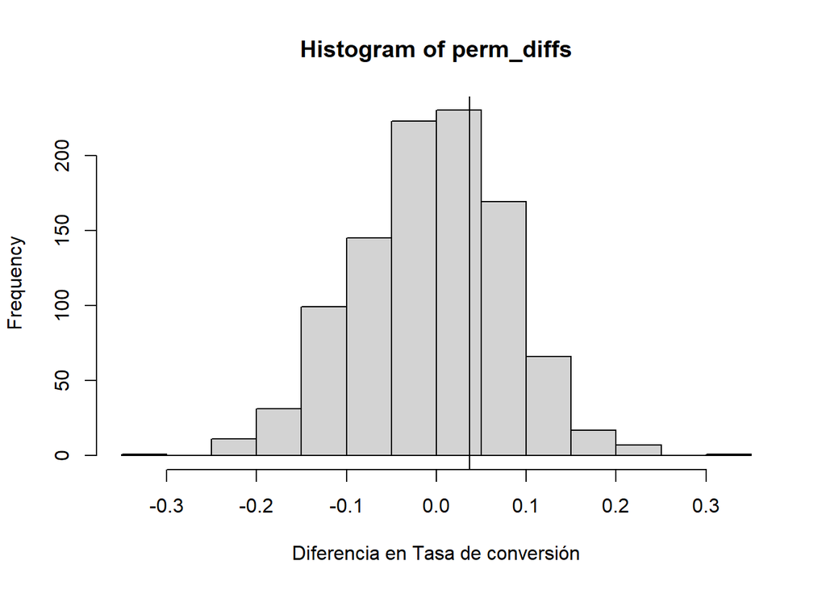

```r
obs_pct_diff = tasa_conversion_a - tasa_conversion_b
perm_diffs <- rep(0,1000) #arreglo con puros 0 donde se guardaran los resultados
#1.- crea una urna que represente a todos los puntos de conversión y no conversión (382, 45845)
conversion <- c(rep(0, 45945), rep(1,382))
for (i in 1:1000){
  perm_diffs[i] = 100*perm_fun(conversion,23739,22588)
}
hist(perm_diffs, xlab='Diferencia en Tasa de conversión')
abline(v=obs_pct_diff)
```

Al mirar este histograma es difícil saber con exactitud cuanto % es que el resultado es mayor a 0.0368 Para esto se puede utilizar el p-value:

```r
mean(perm_diffs > obs_pct_diff)
```

```
## [1] 0.333
```

Ahora, se puede hacer un test binomial para obtener más facil un p-value:

```r
prop.test(x=c(200,182), n=c(23739,22588), alternative = 'greater')
```

```
##
##  2-sample test for equality of proportions with continuity correction
##
## data:  c(200, 182) out of c(23739, 22588)
## X-squared = 0.14893, df = 1, p-value = 0.3498
## alternative hypothesis: greater
## 95 percent confidence interval:
##  -0.001057439  1.000000000
## sample estimates:
##      prop 1      prop 2
## 0.008424955 0.008057376
```

```r
#?prop.test
```

### t-Tests, Multiple Tests

- Todos los experimentos estadísticos necesitan una métrica para evaluarlo, y ver si su comportamiento esta bajo el rango random o es extremo.
- Bonferroni adjustment: dividir tu alpha (critical value) / n observaciones

Es demasiado complejo como estadístico, asegurar que tus experimentos son realmente fehacientes. Para lo que concierne a un científico de datos, aca tienes que echar un ojo:

- For predictive modeling, the risk of getting an illusory model whose apparent efficacy is largely a product of random chance is mitigated by crossvalidation (see “Cross-Validation”), and use of a holdout sample.
- For other procedures without a labeled holdout set to check the model, you must rely on: Awareness that the more you query and manipulate the data, the greater the role that chance might play; and Resampling and simulation heuristics to provide random chance benchmarks against which observed results can be compared.

Un poco de info general:

A null hypothesis, proposes that no significant difference exists in a set of given observations. For the purpose of these tests in general:

- Null: Given two sample means are equal
- Alternate: Given two sample means are not equal